# Data Science II

Session 2: Coordinates, CRS, and Your First Map

Bogdan G. Popescu

bgpopescu@tec.mx

Tec de Monterrey

## Where We Left Off

Last week: Quarto — chunks, options, and sending a single self-contained `.html`.

We drew one map of Mexico and moved on. Today we ask **where** it actually is.

## What You’ll Learn Today

1. Why the Earth’s shape forces us to think about **coordinate reference systems**
2. **Geographic** vs **projected** systems, and what every projection distorts
3. The CRS error you will hit, and `st_transform`
4. What an **`sf` dataframe** is, and how `geom_sf()` reads its geometry column
5. **Vector layers**: points, lines, polygons, and the seven `sf` geometry types
6. Reading a real **shapefile** of Mexico, and what is inside one

## From Documents to Maps

We have a container. Now: how does a place on Earth become a number we can plot?

This is the part people skip. Skipping it is why maps come out **empty, sideways, or refusing to combine**.

## The Earth Is Not a Sphere

- The Earth is not a perfect sphere
- It bulges at the equator — an **oblate spheroid**
- Any flat map is therefore an approximation of an approximation

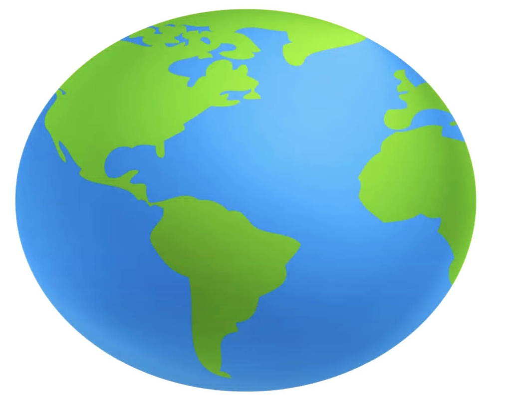

## Meridians

**Meridians** run north–south.

They measure **longitude** — east or west of Greenwich, from -180 to 180.

The **prime meridian** is in red. Mexico, in orange, sits west of it.

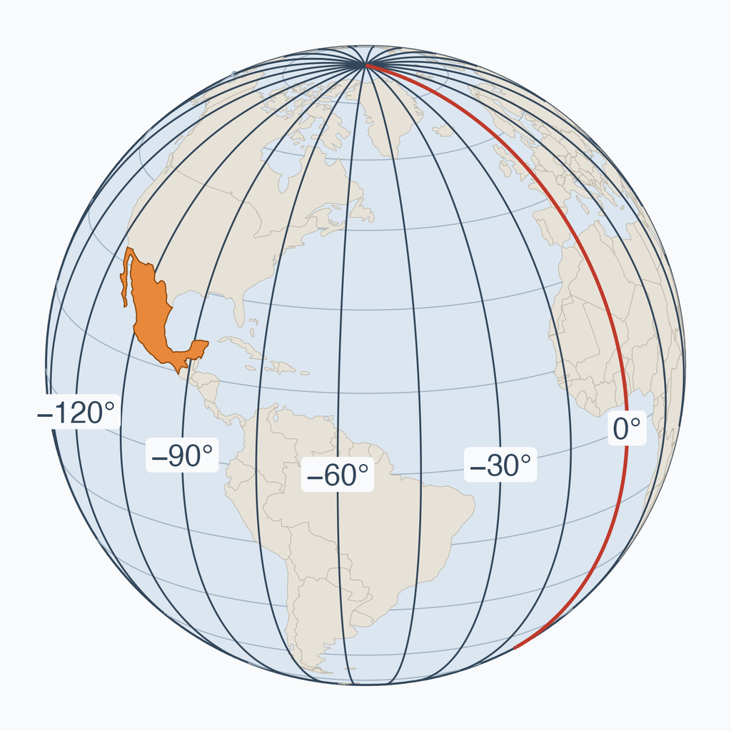

## Parallels

**Parallels** run east–west.

They measure **latitude** — north or south of the equator, from -90 to 90.

The **equator** is in red. Mexico, in orange, sits north of it.

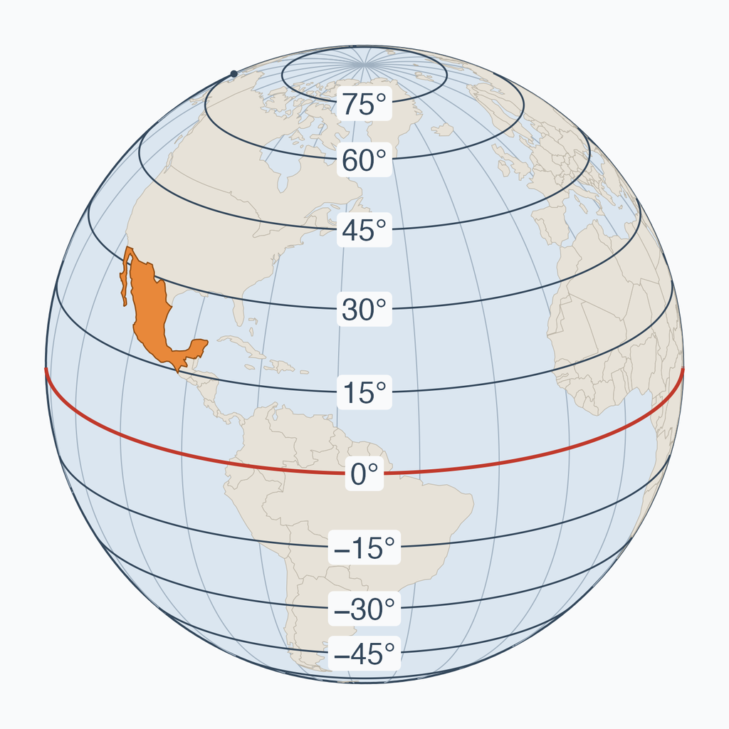

## The Geographic Graticule

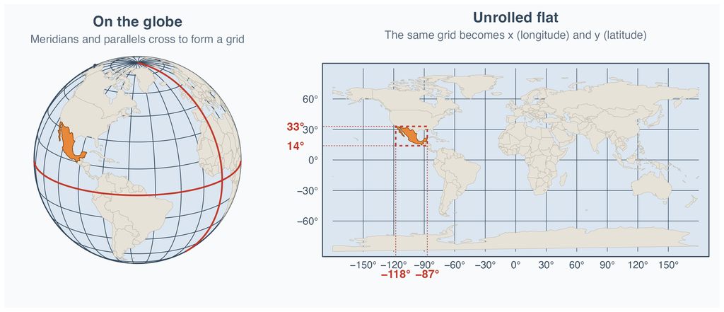

Together they form a grid. Mexico sits roughly between **-118 and -87** longitude, **14 and 33** latitude.

**Warning**

`sf` expects **longitude first, then latitude** — `x` before `y`. Reversing them is the single most common way to put Mexico in the Indian Ocean.

## What Is a Coordinate Reference System?

To place an object on a map you need **two** things:

- the **coordinates** of the object
- a **system of reference** saying how those coordinates relate to a physical location on Earth

A **CRS** has three components:

- **Sphere and ellipsoid** description
- **Geoid**
- **Datum**

## CRS Component 1: Sphere and Ellipsoid

- We can assume the Earth is a perfect sphere — this simplifies the mathematics
- For more accurate measurement we use an **ellipsoid**
- Distance calculations differ between the two

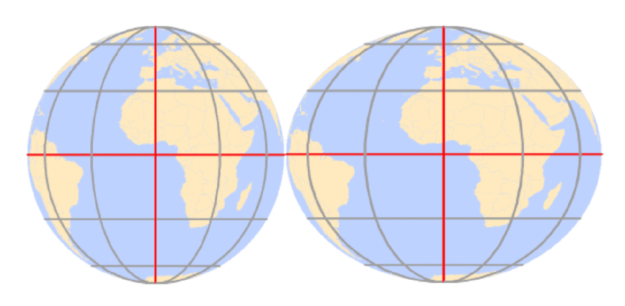

## CRS Component 2: The Geoid

- The Earth’s surface is not smooth
- These undulations are invisible to the eye but matter for local measurement
- Below, the undulations are exaggerated 4,000 times

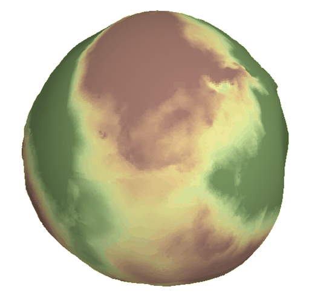

## CRS Component 3: The Datum

To reconcile a simple mathematical model with the undulating shape of the Earth, we:

- align the geoid with the ellipsoid
- map the Earth’s surface features onto that ellipsoid

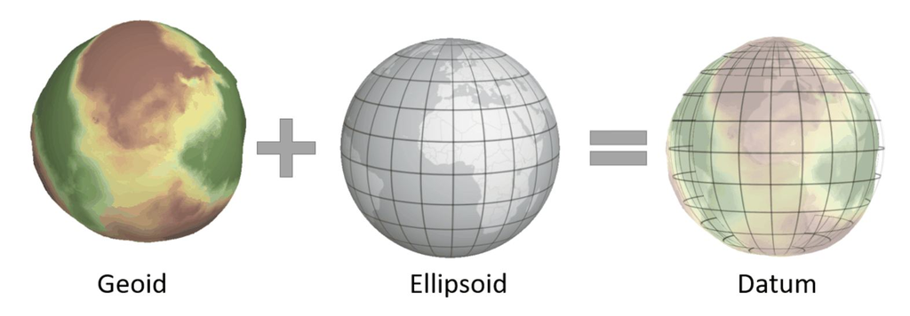

A **datum** is *how you choose to align them*.

## Local and Geocentric Datums

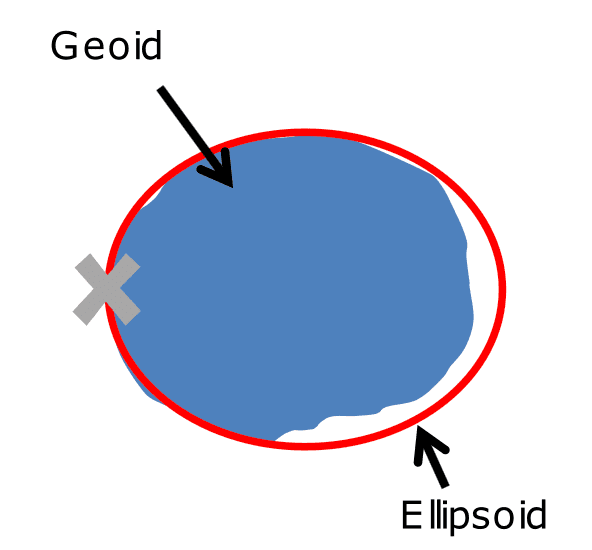

**Local** datums fit one region well:

- NAD27 — continental US
- ED50 — Western Europe

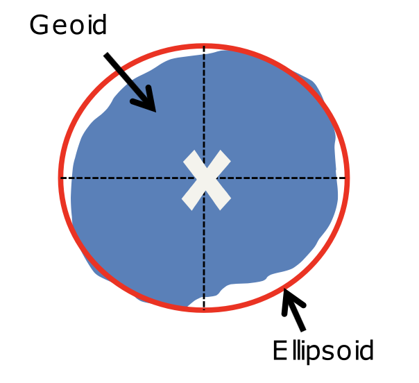

**Geocentric** datums fit the whole world:

- **WGS84**
- NAD83

## Two Families

There are two kinds of CRS, and the difference decides what you can do:

|  | Geographic | Projected |
| --- | --- | --- |
| **Units** | degrees | metres |
| **Shape** | curved surface | flat plane |
| **Example** | WGS84 (EPSG:4326) | Mexico LCC (EPSG:6372) |
| **Good for** | storing, sharing | measuring, mapping |

Going from geographic to projected requires a **mathematical transformation** — and every such transformation distorts something.

## WGS84, or EPSG:4326

The most common geographic system is the **World Geodetic System of 1984**.

It was established because navigation, aviation, and geography needed **global** maps.

Almost everything you download — GADM, INEGI, OpenStreetMap — arrives in WGS84.

`EPSG:4326` is its code. **EPSG codes let you name a CRS with one short integer**, and you will use them constantly.

Every projected system has one too — and choosing between them is the next slide.

**Tip**

**A working rule:** leave your data in WGS84 — it is what you downloaded, and it is what you hand on to someone else. Reproject only when you **measure** — distances, areas, buffers — because those need metres, not degrees.

## Finding an EPSG Code

[figure not shown]

Search any country at epsg.io — the screenshot searches Italy; for **Mexico** the answer is **EPSG:6372**.

## Projected Coordinate Systems

- A **projected coordinate system** is a reference system for identifying locations and measuring features on a flat (map) surface
- Going from a geographic system to a projected one requires **mathematical transformations**
- To perform spatial analyses correctly, all your data has to be in the **same** coordinate system

There is no single correct projection. Each one preserves something and sacrifices something else.

## Types of Projected Coordinate Systems

```r
#Step1: Load the libraries
library(sf)
library(tidyverse)
library(cowplot)
library(ggspatial)
sf_use_s2(FALSE)

#Step2: Get world polygons from the spData package
dunia <- spData::world %>%
  st_as_sf()

#Step3: Draw them in one projection
ggplot() +
  geom_sf(data = dunia) +
  coord_sf(crs = "EPSG: 3857") +
  ggtitle("World Mercator") +
  theme_minimal_grid()
```

## Types of Projected Coordinate Systems

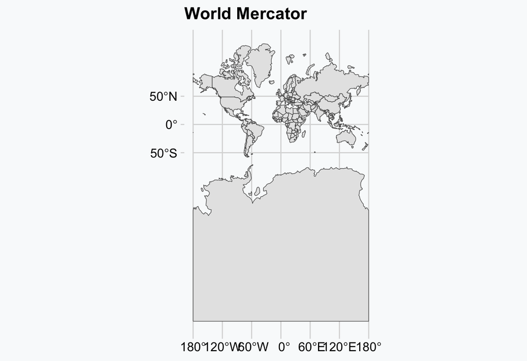

## Types of Projected Coordinate Systems

```r
#Only the CRS code and the title change
ggplot() +
  geom_sf(data = dunia) +
  coord_sf(crs = "ESRI:54030") +
  ggtitle("World Robinson") +
  theme_minimal_grid()
```

## Types of Projected Coordinate Systems

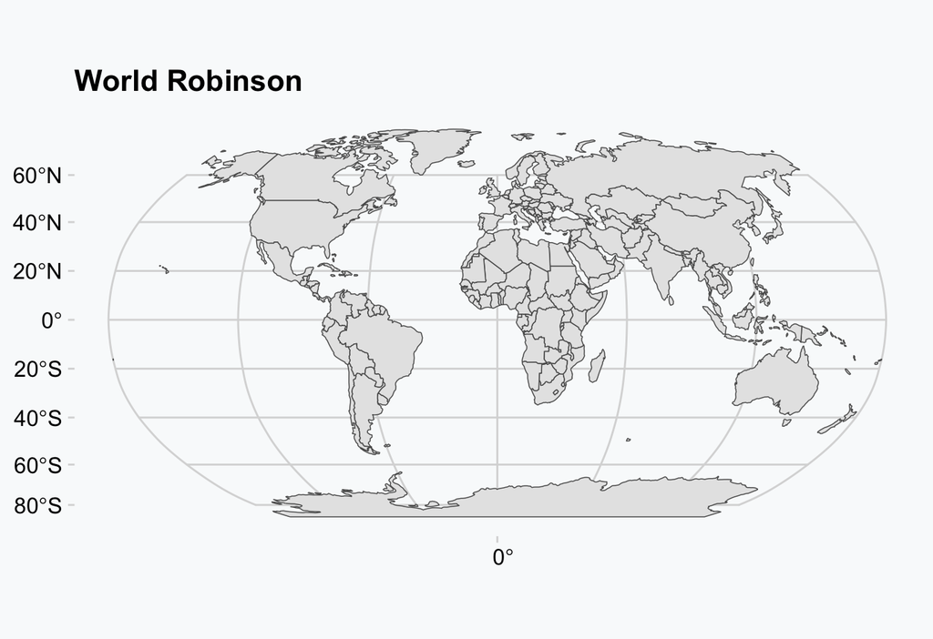

## Types of Projected Coordinate Systems

```r
#Only the CRS code and the title change
ggplot() +
  ggspatial::layer_spatial(data = dunia) +
  coord_sf(crs = "ESRI:54032") +
  ggtitle("World Azimuthal Equidistant") +
  theme_minimal_grid()
```

## Types of Projected Coordinate Systems

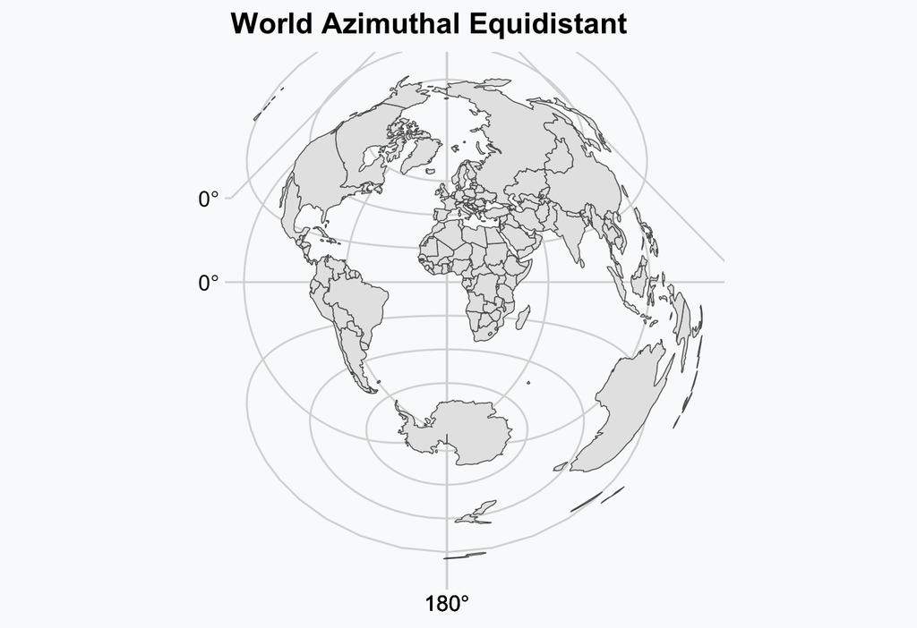

## Types of Projected Coordinate Systems

```r
#Only the CRS code and the title change
ggplot() +
  ggspatial::layer_spatial(data = dunia) +
  coord_sf(crs = "ESRI:54002") +
  ggtitle("World Equidistant Cylindrical") +
  theme_minimal_grid()
```

## Types of Projected Coordinate Systems

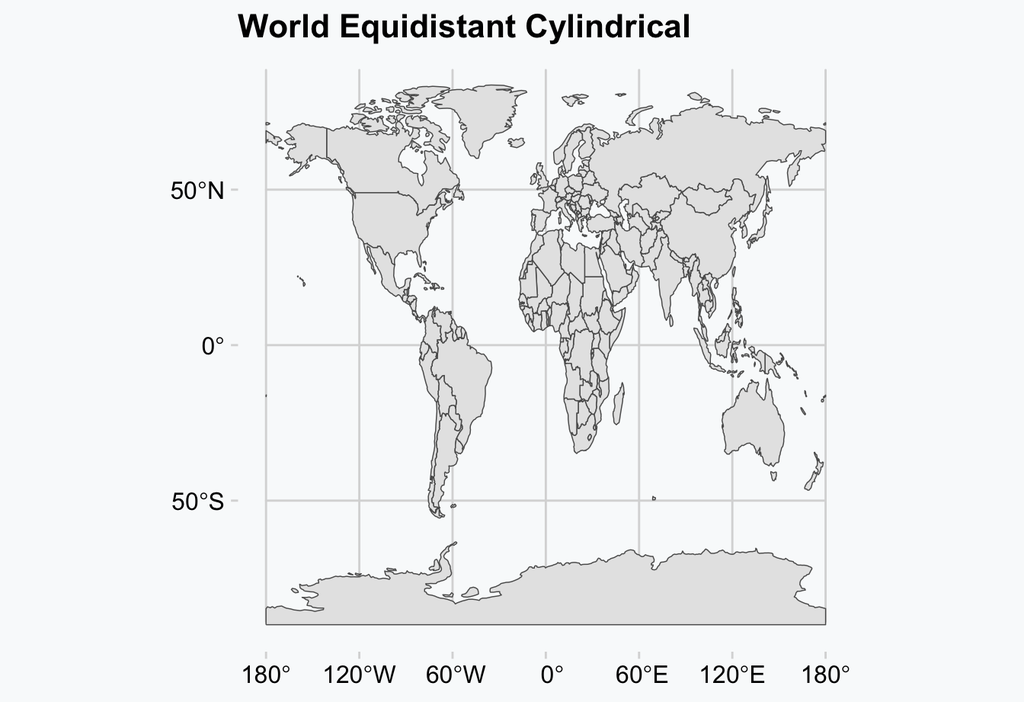

## Types of Projected Coordinate Systems

```r
#Only the CRS code and the title change
ggplot() +
  ggspatial::layer_spatial(data = dunia) +
  coord_sf(crs = "ESRI:54010") +
  ggtitle("World Eckert VI") +
  theme_minimal_grid()
```

## Types of Projected Coordinate Systems

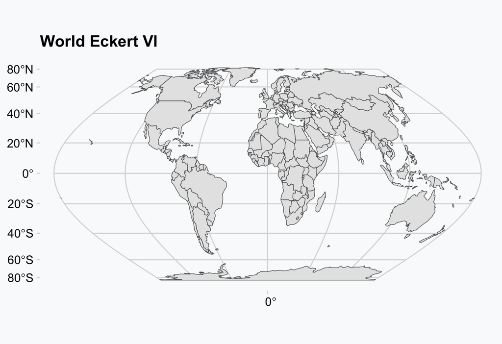

## Types of Projected Coordinate Systems

```r
#Only the CRS code and the title change
ggplot() +
  ggspatial::layer_spatial(data = dunia) +
  coord_sf(crs = "ESRI:54031") +
  ggtitle("World Two Point Equidistant") +
  theme_minimal_grid()
```

## Types of Projected Coordinate Systems

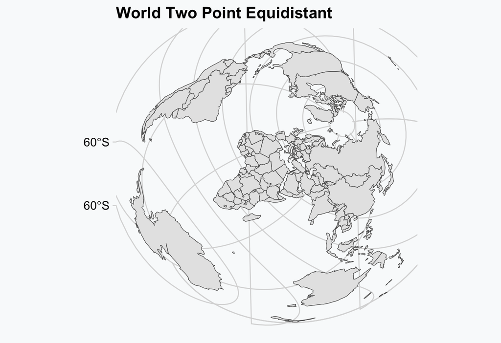

## So Which One for Mexico?

Mercator is the one you have seen most — it is what web maps use — and it is the **worst** choice for a national map. It inflates everything away from the equator.

For Mexico, use **EPSG:6372** (*Mexico ITRF2008 / LCC*):

- a Lambert Conformal Conic, fitted to Mexico’s latitudes
- units in **metres**, so distances and areas are measurable
- the standard for official Mexican cartography

```r
ggplot() + geom_sf(data = mex) + coord_sf(crs = 6372)
```

**Tip**

`coord_sf(crs = ...)` reprojects **for display only**. `st_transform()` changes the data itself. Use `st_transform` when you are going to measure something.

## Why This Matters: The Error You Will Hit

Modern `sf` is good at geodesic mathematics. Ask for a distance between two points stored in degrees and it still returns a sensible answer in metres.

So CRS mistakes rarely corrupt your numbers **quietly**. They stop you **loudly**, the moment you combine two layers:

```r
#Step1: Make a point for Mexico City, in WGS84 (degrees)
cdmx <- st_as_sf(data.frame(lon = -99.1332, lat = 19.4326),
                 coords = c("lon", "lat"), crs = 4326)

#Step2: Project the states to EPSG:6372 (metres) -- a DIFFERENT crs
mex_projected <- st_transform(mex1, 6372)

#Step3: Try to combine them
st_join(cdmx, mex_projected)
```

```
Error in `st_geos_binop()`:
! st_crs(x) == st_crs(y) is not TRUE
```

You will meet this exact error in **Session 4**. Now you know what it means.

## `st_transform` Is the Fix

Put both layers in the same CRS. That is the whole solution.

```r
st_crs(cdmx)$input
```

```
[1] "EPSG:4326"
```

```r
st_crs(mex_projected)$input
```

```
[1] "EPSG:6372"
```

```r
#Step1: Put the point into the SAME crs as the polygons, then join
result <- st_join(st_transform(cdmx, 6372), mex_projected)

#Step2: Which state did the point land in?
result$NAME_1
```

```
[1] "Distrito Federal"
```

**Tip**

Habit worth forming: **transform everything to one CRS immediately after reading it**, before you do anything else.

## Or Just Stick to WGS84

Both layers have to use the same CRS, but it does not have to be `6372`.

```r
#Step1: Bring the polygons back to the CRS the files arrived in
mex_wgs <- st_transform(mex_projected, 4326)

#Step2: The same join, with nothing done to the point
st_join(cdmx, mex_wgs)$NAME_1
```

```
[1] "Distrito Federal"
```

Same answer. For a point-in-polygon question, WGS84 is enough.

**Tip**

Keep everything in WGS84 as you read it. Project to `6372` only when you need to measure something: a distance, an area, a buffer.

## A Warning About Boundary Data

Look at that answer again: **“Distrito Federal”**.

GADM still uses the name retired in **2016**, when the Distrito Federal became Ciudad de México.

Boundary files carry their own **vintage** and their own **politics**:

- names change
- municipios split and merge
- state borders are occasionally disputed

**Important**

Always check *when* your boundary file was made, and whether its keys match the dataset you plan to join to it. This is one more reason to prefer **INEGI** for official Mexican work.

## What an `sf` Dataframe Actually Is

Start with an ordinary dataframe. Nothing spatial about it — two of the columns just happen to hold numbers we call coordinates.

```r
#Step1: A plain dataframe
clinics <- data.frame(
  city = c("Monterrey", "Guadalajara", "Mérida"),
  beds = c(420, 310, 180),
  lon  = c(-100.3161, -103.3496, -89.5926),
  lat  = c(  25.6866,   20.6597,  20.9674))

#Step2: Promote it to sf -- lon FIRST, then lat, and say which CRS they are in
clinics_sf <- st_as_sf(clinics, coords = c("lon", "lat"), crs = 4326)

clinics_sf
```

```
Simple feature collection with 3 features and 2 fields
Geometry type: POINT
Dimension:     XY
Bounding box:  xmin: -103.3496 ymin: 20.6597 xmax: -89.5926 ymax: 25.6866
Geodetic CRS:  WGS 84
         city beds                  geometry
1   Monterrey  420 POINT (-100.3161 25.6866)
2 Guadalajara  310 POINT (-103.3496 20.6597)
3      Mérida  180  POINT (-89.5926 20.9674)
```

`lon` and `lat` are **gone**. A single `geometry` column took their place, and the CRS is now attached to the object.

## Still a Dataframe, With One Extra Column

```r
#Step1: It is BOTH an sf object and a data.frame
class(clinics_sf)
```

```
[1] "sf"         "data.frame"
```

```r
#Step2: The columns you started with, plus one
names(clinics_sf)
```

```
[1] "city"     "beds"     "geometry"
```

```r
#Step3: sf remembers which column holds the geometry
attr(clinics_sf, "sf_column")
```

```
[1] "geometry"
```

```r
#Step4: And that column is a list of POINTs
st_geometry(clinics_sf)
```

```
Geometry set for 3 features
Geometry type: POINT
Dimension:     XY
Bounding box:  xmin: -103.3496 ymin: 20.6597 xmax: -89.5926 ymax: 25.6866
Geodetic CRS:  WGS 84
```

**Tip**

`sf` tracks the geometry column **by name**. That is how every `st_` function knows which column to operate on, and why you never pass the coordinates around yourself.

## How `ggplot` Finds the Geometry

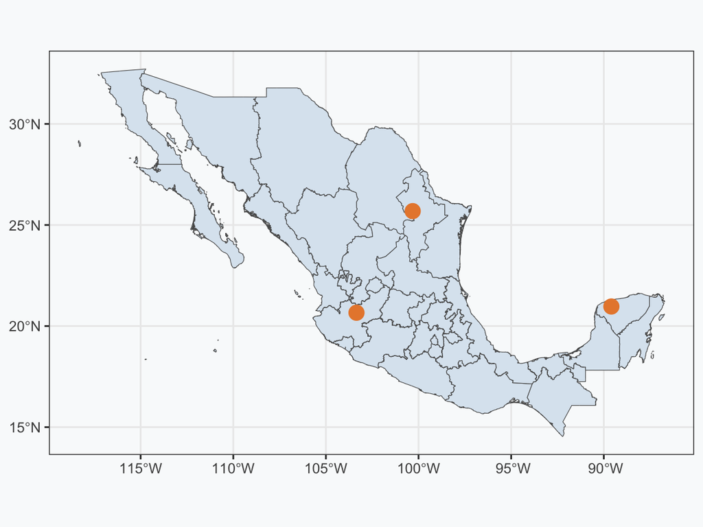

```r
#Note: no aes(x = , y = ) anywhere
ggplot() +
  geom_sf(data = mex1, fill = "#dbe6f0") +
  geom_sf(data = clinics_sf,
          colour = "#e8883a", size = 4) +
  theme_bw()
```

`geom_sf()` looks up the column named by `sf_column` and draws **that**. You never tell it where `x` and `y` are — it already knows.

Without `sf` you would be writing `geom_point(data = clinics, aes(x = lon, y = lat))`, and you would have to handle the projection yourself.

## The Geometry Column Decides the Mark

The **same** `geom_sf()` call draws a dot, a line, or a filled shape. What changes is what is sitting in the geometry column.

```r
#Step1: Three objects, three geometry types, identical attributes
p <- st_sf(kind = "POINT",      geometry = st_sfc(st_point(c(5, 4))))
l <- st_sf(kind = "LINESTRING", geometry = st_sfc(
             st_linestring(rbind(c(1,2), c(5,6), c(9,3)))))
a <- st_sf(kind = "POLYGON",    geometry = st_sfc(
             st_polygon(list(rbind(c(2,2), c(8,2), c(8,6), c(2,2))))))

#Step2: One geom_sf() call each -- nothing else differs
patchwork::wrap_plots(
  ggplot() + geom_sf(data = p, size = 5) + ggtitle("POINT")      + theme_void(),
  ggplot() + geom_sf(data = l, linewidth = 1.2) + ggtitle("LINESTRING") + theme_void(),
  ggplot() + geom_sf(data = a, fill = "#dbe6f0") + ggtitle("POLYGON") + theme_void())
```

This is why the next slides matter: the **geometry type** is what your map will look like, before you choose a single colour.

## The Geometry Column Decides the Mark

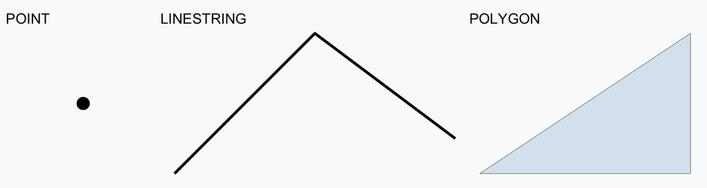

## Attributes Colour It, Geometry Places It

`aes()` still maps the **ordinary** columns. The geometry column decides *where*; the attributes decide *how it looks*.

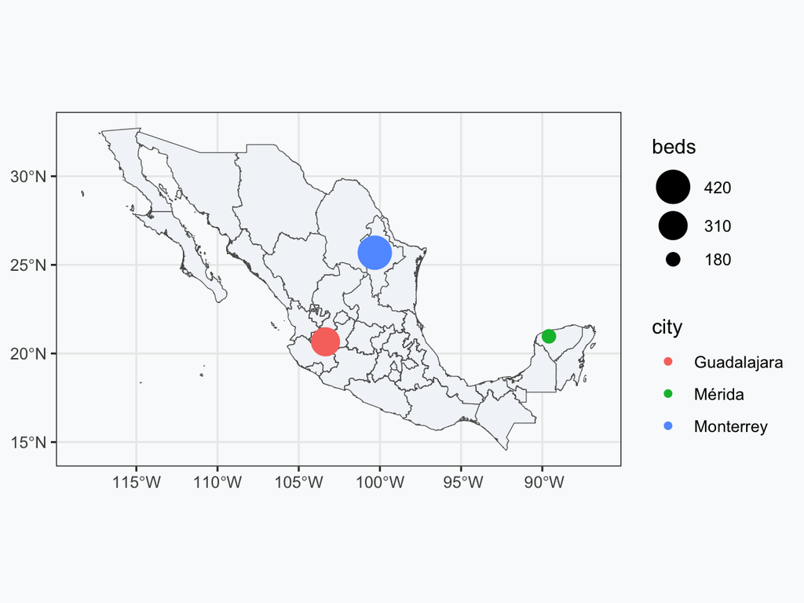

```r
ggplot() +
  geom_sf(data = mex1, fill = "#f2f5f8") +
  geom_sf(data = clinics_sf,
          aes(size = beds, colour = city)) +
  scale_size(range = c(3, 8),
             breaks = clinics_sf$beds) +
  theme_bw()
```

`beds` and `city` are plain columns — exactly the `aes()` you already know from `ggplot2`. Nothing spatial about that half of the grammar.

## Vector and Raster

- Spatial data comes as a **vector** or a **raster**
- A river as a vector (left) and as a raster (right)

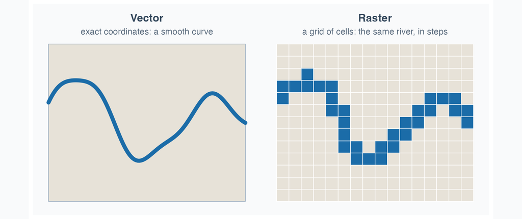

In these five sessions we work with **vectors**. Rasters are a course of their own.

## Vector Layers

A vector layer is a set of **geometries** attached to a table of **non-spatial attributes**.

Geometries are sequences of coordinates forming **points**, **lines**, or **polygons**.

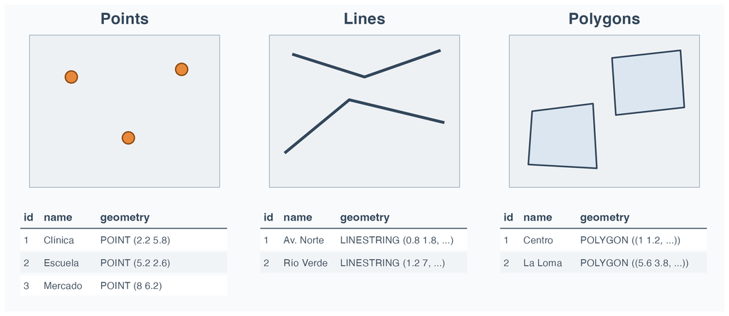

## The Seven Simple Feature Types

`sf` builds every geometry from one of seven constructors:

| one piece | several pieces |
| --- | --- |
| `st_point` | `st_multipoint` |
| `st_linestring` | `st_multilinestring` |
| `st_polygon` | `st_multipolygon` |

`st_geometrycollection` holds a mixture of the other six — **single or multi**, in any combination.

## `POINT` and `MULTIPOINT`

```r
x <- st_sf(name = c("one clinic", "three clinics"),
           geometry = st_sfc(
             st_point(c(5, 4.2)),
             st_multipoint(rbind(c(2.6,5.6), c(5,2.6), c(7.6,5.6)))))

x$type <- st_geometry_type(x)
as.data.frame(x)[, c("name", "type", "geometry")]
```

```
           name       type                       geometry
1    one clinic      POINT                  POINT (5 4.2)
2 three clinics MULTIPOINT MULTIPOINT ((2.6 5.6), (5 2...
```

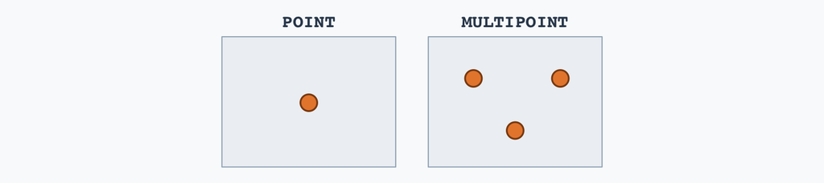

## `LINESTRING` and `MULTILINESTRING`

```r
x <- st_sf(name = c("one road", "two roads"),
           geometry = st_sfc(
             st_linestring(rbind(c(1,2), c(4,5.8), c(9,3))),
             st_multilinestring(list(rbind(c(1,6.5), c(4,4.6), c(9,6.2)),
                                     rbind(c(1,2.2), c(4.5,1.5), c(9,2.8))))))

x$type <- st_geometry_type(x)
as.data.frame(x)[, c("name", "type", "geometry")]
```

```
       name            type                       geometry
1  one road      LINESTRING   LINESTRING (1 2, 4 5.8, 9 3)
2 two roads MULTILINESTRING MULTILINESTRING ((1 6.5, 4 ...
```

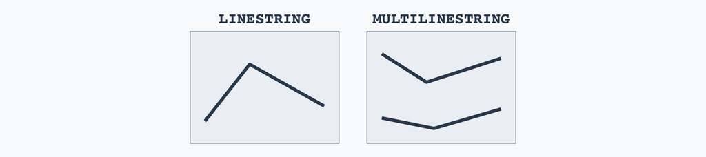

## `POLYGON` and `MULTIPOLYGON`

```r
x <- st_sf(name = c("one state", "state + islands"),
           geometry = st_sfc(
             st_polygon(list(rbind(c(2,1.8), c(7,1.6), c(8,4.8), c(5,6.8), c(2,1.8)))),
             st_multipolygon(list(
               list(rbind(c(1.4,1.8), c(5.4,1.6), c(6.1,4.8), c(3.4,6.2), c(1.4,1.8))),
               list(rbind(c(7,5.2), c(8.3,4.9), c(8.6,6.4), c(7.2,6.6), c(7,5.2)))))))

x$type <- st_geometry_type(x)
as.data.frame(x)[, c("name", "type", "geometry")]
```

```
             name         type                       geometry
1       one state      POLYGON POLYGON ((2 1.8, 7 1.6, 8 4...
2 state + islands MULTIPOLYGON MULTIPOLYGON (((1.4 1.8, 5....
```

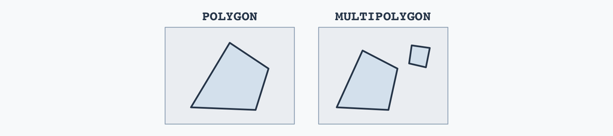

## `GEOMETRYCOLLECTION`

```r
ring <- rbind(c(5.2,4.6), c(9,4.6), c(9,7.2), c(5.2,7.2), c(5.2,4.6))

x <- st_sf(name = "one feature",
           geometry = st_sfc(st_geometrycollection(list(
             st_point(c(2.2, 6.2)),
             st_linestring(rbind(c(1,1.6), c(4.2,3.6), c(9,1.8))),
             st_polygon(list(ring))))))

x$type <- st_geometry_type(x)
as.data.frame(x)[, c("name", "type", "geometry")]
```

```
         name               type                       geometry
1 one feature GEOMETRYCOLLECTION GEOMETRYCOLLECTION (POINT (...
```

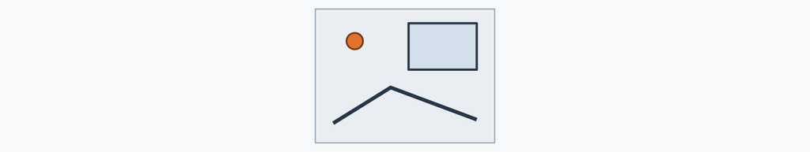

A point, a line and a polygon in **one row**. `st_intersection()` returns one when two layers meet at both an edge and a corner.

## It Holds the `MULTI` Types Too

The parts do not have to be single geometries — `MULTIPOINT`, `MULTILINESTRING` and `MULTIPOLYGON` go in just as happily.

```r
st_geometrycollection(list(
  st_multipoint(rbind(c(1,1), c(2,2))),
  st_multilinestring(list(rbind(c(0,0), c(1,1)), rbind(c(2,2), c(3,3)))),
  st_multipolygon(list(list(rbind(c(0,0), c(1,0), c(1,1), c(0,0)))))))
```

You can mix the two families in one collection — a `POINT` next to a `MULTIPOINT` is fine:

```r
st_geometrycollection(list(st_point(c(0,0)),
                           st_multipoint(rbind(c(1,1), c(2,2)))))
```

## Two Things It Will Not Do

**1. A collection cannot contain another collection.** `sf` refuses:

```r
st_geometrycollection(list(st_point(c(0,0)),
                           st_geometrycollection(list(st_point(c(1,1))))))
```

```
Error in `st_geometrycollection()`:
! all(cls[2, ] != "GEOMETRYCOLLECTION") is not TRUE
```

**2. `st_collection_extract()` pulls out a *family*, not an exact type.** Asking for `"POLYGON"` also returns any `MULTIPOLYGON` inside:

```r
gc <- st_sfc(st_geometrycollection(list(
  st_multipolygon(list(list(rbind(c(0,0), c(1,0), c(1,1), c(0,0))))))))

st_geometry_type(st_collection_extract(gc, "POLYGON"))
```

```
[1] MULTIPOLYGON
18 Levels: GEOMETRY POINT LINESTRING POLYGON MULTIPOINT ... TRIANGLE
```

**Note**

That is a convenience, not a bug — the three arguments `"POINT"`, `"LINESTRING"` and `"POLYGON"` each mean “everything of that dimension”. Use `st_cast()` afterwards if you need one exact type.

## Which Type Did You Get?

```r
#Step1: Every geometry in a layer shares one type
table(as.character(st_geometry_type(mex1)))
```

```
MULTIPOLYGON
          32
```

```r
#Step2: One row can still be many pieces
parts <- lengths(st_geometry(mex1))
names(parts) <- mex1$NAME_1
head(sort(parts, decreasing = TRUE), 3)
```

```
         Tamaulipas             Sinaloa Baja California Sur
                261                 199                 180
```

**Note**

15 of the 32 states are a single piece, yet the type is still `MULTIPOLYGON` — every geometry in one layer must share a type. `st_cast()` converts when a function insists on one or the other.

## Where to Get Shapefiles: GADM

Country and subnational boundaries for the whole world: https://gadm.org

[figure not shown]

## Choosing a Country

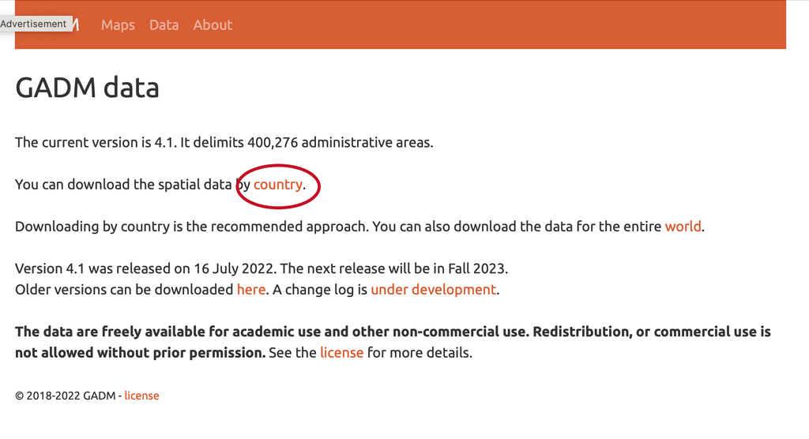

## Choosing a Country

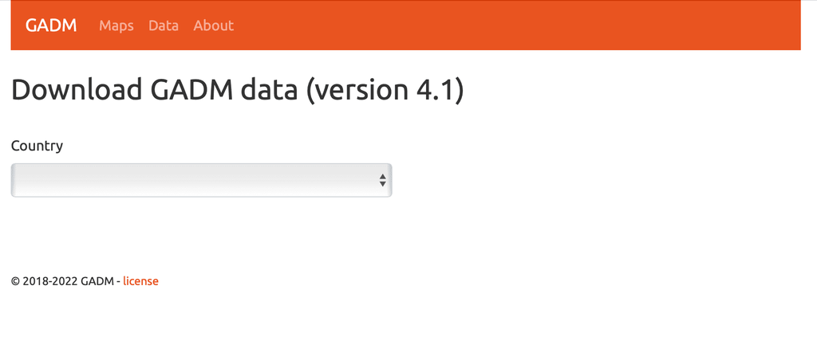

## Choosing a Country

[figure not shown]

## Choosing a Country

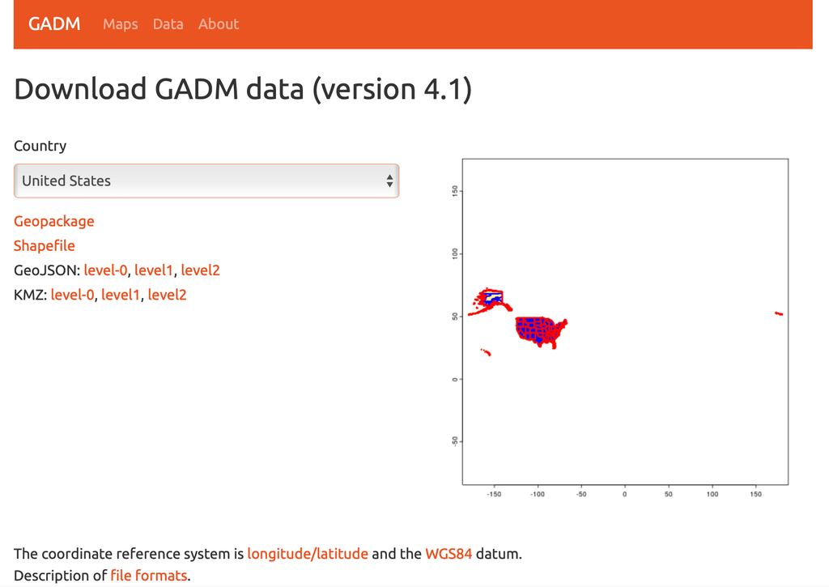

GADM gives you nested levels: `_0` country, `_1` states, `_2` municipios. For Mexico that is **1**, **32**, and **2,466** features.

## What You Download

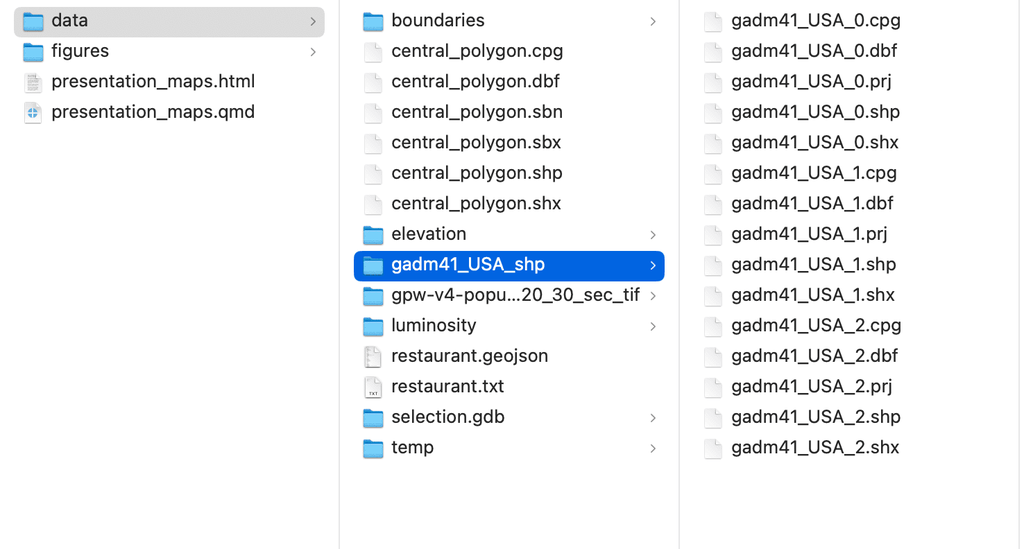

**Warning**

A “shapefile” is **not one file**. It is at least `.shp` (geometry), `.dbf` (attributes), `.shx` (index), and `.prj` (the CRS). Move them together or the layer breaks — and a missing `.prj` means R has no idea where on Earth your data is.

## A Shapefile Is at Least Four Files

| File | What it holds | Without it |
| --- | --- | --- |
| `.shp` | the geometry — every coordinate | nothing to draw |
| `.shx` | an index into `.shp` | the file will not open |
| `.dbf` | the attribute table, one row per shape | no names, no values |
| `.prj` | the CRS, written out as text | R cannot place it on Earth |
| `.cpg` *(optional)* | the text encoding of `.dbf` | accents arrive mangled |

`.shp`, `.shx` and `.dbf` are mandatory; `.prj` is needed in practice. They are linked only by a shared basename, `gadm41_MEX_1`. Rename one and the layer stops opening.

The `.shp` is 11.5 MB of an 11.6 MB download. The rest are a few kilobytes, but you still need them.

## The `.prj` Is Just a Line of Text

```r
prj <- readLines("../data/gadm41_MEX_shp/gadm41_MEX_1.prj", warn = FALSE)
prj <- gsub("],", "],\n", prj, fixed = TRUE)
prj <- gsub(",DATUM", ",\n  DATUM", prj, fixed = TRUE)
cat(gsub(",SPHEROID", ",\n    SPHEROID", prj, fixed = TRUE))
```

```
GEOGCS["GCS_WGS_1984",
  DATUM["D_WGS_1984",
    SPHEROID["WGS_1984",6378137.0,298.257223563]],
PRIMEM["Greenwich",0.0],
UNIT["Degree",0.0174532925199433]]
```

That text is how `st_read()` knows the data is in WGS84. Without the `.prj` the geometry still loads, but with no CRS attached to it.

## The `.cpg` and Your Accents

```r
#The .cpg says how the text in the .dbf is encoded
readLines("../data/gadm41_MEX_shp/gadm41_MEX_1.cpg")
```

```
[1] "UTF-8"
```

`UTF-8` is why *Yucatán* and *Querétaro* survive the trip.

A wrong `.cpg` gives you `Yucatï¿½n`, and then a join on state names matches nothing.

## The Shapefile Is Not the Only Format

| Type | Format | Extension |
| --- | --- | --- |
| Binary | ESRI Shapefile | `.shp`, `.shx`, `.dbf`, `.prj` |
|  | GeoPackage (GPKG) | `.gpkg` |
| Plain text | GeoJSON | `.json` or `.geojson` |
|  | GPS Exchange Format (GPX) | `.gpx` |
|  | Keyhole Markup Language (KML) | `.kml` |
| Spatial database | PostgreSQL / PostGIS |  |

The shapefile has real limits: four files to keep together, and column names truncated to 10 characters.

`st_read()` reads all of them, so the format matters less than you might expect.

## Same States, Three Formats

```r
#Step1: st_read() does not care which container it is given
gj <- st_read("../data/mex_formats/mex_states.geojson", quiet = TRUE)
gp <- st_read("../data/mex_formats/mex_states.gpkg",    quiet = TRUE)

#Step2: the same sf object comes back either way
c(geojson = nrow(gj), gpkg = nrow(gp))
```

```
geojson    gpkg
     32      32
```

Same 32 states, same columns: 0.45 MB as GeoJSON against 0.27 MB as GeoPackage. Plain text takes more room than a binary database.

## Prefer INEGI for Official Work

GADM is convenient and global. But for Mexican policy work, **INEGI’s Marco Geoestadístico** is better:

- it carries `CVE_ENT` and `CVE_MUN`, the keys **every other INEGI dataset** joins on
- the boundaries are the official ones
- it goes down to *localidad* and *AGEB*

https://www.inegi.org.mx/temas/mg/

We use GADM today because it is one click. Use INEGI for your reto.

## The Same Thing, With 32 Real Rows

The clinics were three rows we typed by hand. A real shapefile is the **identical structure** — just wider, and with polygons where we had points.

```r
#Step1: Read the state boundaries
mex_states <- st_read("../data/gadm41_MEX_shp/gadm41_MEX_1.shp", quiet = TRUE)

#Step2: The same two classes, the same sf_column -- 32 rows instead of 3
class(mex_states)
```

```
[1] "sf"         "data.frame"
```

```r
dim(mex_states)
```

```
[1] 32 12
```

```r
attr(mex_states, "sf_column")
```

```
[1] "geometry"
```

Nothing new to learn. You already know how to read this object.

## The Same Thing, With 32 Real Rows

```r
mex_states[1:3, c("NAME_1", "TYPE_1")]
```

```
Simple feature collection with 3 features and 2 fields
Geometry type: MULTIPOLYGON
Dimension:     XY
Bounding box:  xmin: -118.3665 ymin: 21.62227 xmax: -101.8353 ymax: 32.71863
Geodetic CRS:  WGS 84
               NAME_1 TYPE_1                       geometry
1      Aguascalientes Estado MULTIPOLYGON (((-102.0659 2...
2     Baja California Estado MULTIPOLYGON (((-114.1228 2...
3 Baja California Sur Estado MULTIPOLYGON (((-109.9104 2...
```

`MULTIPOLYGON` in the geometry column, so `geom_sf()` will draw filled shapes — exactly as on the POINT / LINESTRING / POLYGON slide earlier.

## Why That Matters

This is the most important idea in the next four weeks:

**Everything you know from `dplyr` still works.**

`filter`, `mutate`, `group_by`, `summarise`, `left_join` — all of it. There is simply an extra `geometry` column that travels along with every row.

**Tip**

`st_drop_geometry()` gives you the plain table back when you want to inspect the attributes without pages of coordinates.

## `st_simplify`: Making Maps Render Fast

Detailed boundaries are slow to draw, and at national scale you cannot see the detail anyway.

```r
#Step1: Simplify the boundaries (0.02 degrees is roughly 2 km)
mex_simple <- st_simplify(mex_states, dTolerance = 0.02)

#Step2: Compare the sizes before and after
format(object.size(mex_states), units = "MB")
```

```
[1] "11.9 Mb"
```

```r
format(object.size(mex_simple), units = "MB")
```

```
[1] "0.1 Mb"
```

**11.9 MB to 0.1 MB** — a hundredfold reduction, with no visible difference at this scale.

**Warning**

`dTolerance` is in the **units of your CRS**. In WGS84 that is *degrees*, so `0.02` is roughly 2 km. `sf` warns you about this. Across Mexico a degree of longitude varies by about 15% between Chiapas and the northern border — invisible at national scale. Project first only if you need the tolerance to mean exact metres.

## `st_simplify`: Before and After

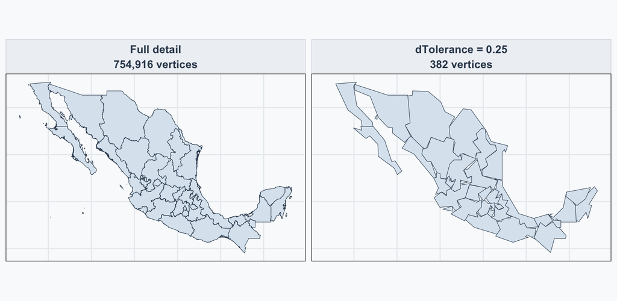

At `0.02`, the value used above, the change is invisible at this scale. At `0.25` the coastline collapses into straight lines.